# README

# retireMC: Monte Carlo Retirement Planning in R

An R package for stochastic retirement planning using Monte Carlo simulation. Quantifies sequence-of-returns risk and provides probabilistic retirement outcomes.

## Installation

You can install the development version from GitHub:

```r
# Install devtools if not already installed
if (!require("devtools")) {
  install.packages("devtools")
}

# Install retireMC from GitHub
devtools::install_github("yalin-lynn/retireMC")
```

### Dependencies

This package requires the following R packages:

ggplot2 (for plotting)

dplyr (for data manipulation)

tidyr (for data reshaping)

tibble (for data frames)

magrittr (for pipe operator)

These will be installed automatically when you install retireMC.

### Features

Dual Return Models: Geometric Brownian Motion and empirical resampling

Flexible Withdrawal Strategies: Constant, inflation-adjusted withdrawals

Comprehensive Risk Metrics: Success rates, ruin probabilities, wealth distributions

Professional Visualization: Percentile bands and trajectory plots

Historical Data: Built-in S&P 500 data (2000-2009) for empirical analysis

### Quick Start

```r
library(retireMC)

# Basic Monte Carlo simulation
results <- run_mc(
  initial = 1000000,    # $1,000,000 initial portfolio
  n_years = 30,         # 30-year retirement horizon
  n_sims = 5000,        # 5,000 simulations
  withdraw = 60000,     # $60,000 annual withdrawal
  infl_rate = 0.02,     # 2% inflation adjustment
  returns_args = list(
    model = "gbm",      # Use GBM model
    mu = 0.07,          # 7% expected return
    sigma = 0.15        # 15% volatility
  )
)

# View results
cat("Success rate:", round(results$metrics$success_rate * 100, 1), "%\n")
```

```
## Success rate: 39.7 %
```

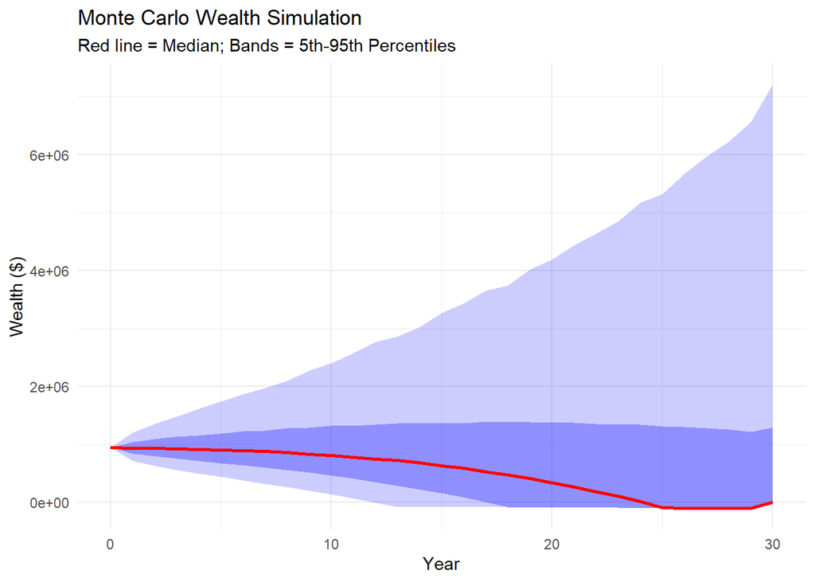

```r
# Create visualization
plot_percentile_bands(results$wealth)
```

### Using Historical Data

```r
# Use S&P 500 historical returns (2000-2009)
sp500_returns <- sp500_annual_sample()

results_historical <- run_mc(
  initial = 1000000,
  n_years = 30,
  n_sims = 5000,
  withdraw = 60000,
  infl_rate = 0.02,
  returns_args = list(
    model = "empirical",
    empirical_returns = sp500_returns
  )
)

cat("Historical data success rate:",
    round(results_historical$metrics$success_rate * 100, 1), "%\n")
```

```
## Historical data success rate: 3.4 %
```

### Core Functions

simulate_returns()

Generate stochastic market returns using GBM or empirical resampling.

```r
returns <- simulate_returns(
  n_years = 30,
  n_sims = 1000,
  model = "gbm",        # or "empirical"
  mu = 0.07,
  sigma = 0.15
)
```

simulate_wealth()

Project wealth trajectories given returns and withdrawal strategy.

```r
wealth <- simulate_wealth(
  initial = 1000000,
  returns = returns,
  withdraw = 60000,
  withdraw_timing = "start"  # or "end"
)
```

compute_ruin()

Calculate retirement success metrics and ruin probabilities.

```r
metrics <- compute_ruin(wealth)
success_rate <- metrics$success_rate
ruin_by_year <- metrics$ruin_prob_by_year
```

plot_percentile_bands()

Visualize Monte Carlo simulation results.

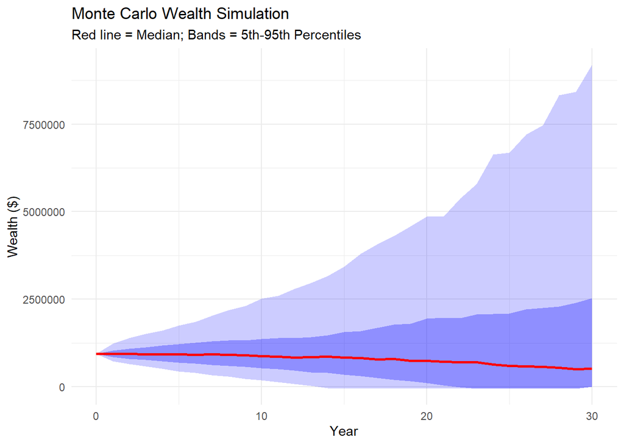

```r
plot_percentile_bands(wealth)
```

run_mc()

Complete workflow function for retirement analysis.

```r
results <- run_mc(initial = 1000000, n_years = 30, withdraw = 60000)
```

Data Functions

```r
# Get S&P 500 returns vector for simulations
returns_vector <- sp500_annual_sample()

# Get full dataset with years
full_data <- sp500_annual_data()
print(full_data)
```

```
##    year return
## 1  2000 -0.093
## 2  2001 -0.119
## 3  2002 -0.223
## 4  2003  0.268
## 5  2004  0.103
## 6  2005  0.041
## 7  2006  0.158
## 8  2007  0.057
## 9  2008 -0.370
## 10 2009  0.258
```

### Data

The package includes annual S&P 500 returns from 2000-2009:

Year Return 2000 -9.3% 2001 -11.9% 2002 -22.3% 2003 +26.8% 2004 +10.3% 2005 +4.1% 2006 +15.8% 2007 +5.7% 2008 -37.0% 2009 +25.8%

### Sensitivity Analysis

```r
# Test different withdrawal rates
withdrawal_rates <- c(40000, 50000, 60000)

for (rate in withdrawal_rates) {
  results <- run_mc(
    initial = 1000000,
    n_years = 30,
    n_sims = 1000,
    withdraw = rate,
    returns_args = list(model = "gbm", mu = 0.07, sigma = 0.15)
  )
  cat("$", rate, " withdrawal: ",
      round(results$metrics$success_rate * 100, 1), "% success rate\n", sep = "")
}
```

```
## $40000 withdrawal: 78.2% success rate
## $50000 withdrawal: 60.8% success rate
## $60000 withdrawal: 39.1% success rate
```

### Compare Models

```r
# Compare GBM vs historical models
gbm_results <- run_mc(initial = 1000000, n_years = 30, n_sims = 1000,
                     returns_args = list(model = "gbm", mu = 0.07, sigma = 0.15))

historical_results <- run_mc(initial = 1000000, n_years = 30, n_sims = 1000,
                           returns_args = list(model = "empirical",
                                             empirical_returns = sp500_annual_sample()))

cat("GBM success rate:", round(gbm_results$metrics$success_rate * 100, 1), "%\n")
```

```
## GBM success rate: 37.7 %
```

```r
cat("Historical success rate:", round(historical_results$metrics$success_rate * 100, 1), "%\n")
```

```
## Historical success rate: 2.8 %
```

### Wealth Distribution Analysis

```r
# Analyze final wealth distribution
results <- run_mc(initial = 1000000, n_years = 30, n_sims = 5000, withdraw = 60000)
final_wealth <- results$wealth[31, ]

cat("Final Wealth Distribution:\n")
```

```
## Final Wealth Distribution:
```

```r
cat("5th percentile: $", round(quantile(final_wealth, 0.05), 0), "\n")
```

```
## 5th percentile: $ 0
```

```r
cat("Median: $", round(median(final_wealth), 0), "\n")
```

```
## Median: $ 0
```

```r
cat("95th percentile: $", round(quantile(final_wealth, 0.95), 0), "\n")
```

```
## 95th percentile: $ 7412396
```

### Empirical Resampling

Historical returns are sampled with replacement to preserve actual market patterns including volatility clustering and tail events.

### Package Structure

retireMC/ ├── R/ │ ├── simulate_returns.R │ ├── simulate_wealth.R │ ├── sp500_data.R │ ├── metrics_and_summaries.R │ ├── plotting.R │ ├── utils.R │ └── globals.R ├── inst/extdata/ │ └── sp500_annual_sample.csv ├── man/ │ └── (documentation files) ├── tests/ │ └── testthat.R └── vignettes/ └── introduction.Rmd